# 07_Extract_Targets

Calen P. Ryan

02 December, 2018

1. Pull those with DNAm
2. Pull those with placenta
3. Pull those who were pregannt in 2005
4. Pull those who were breastfeeding in 2005
5. Make sure I don’t have any of the mismatched IDs or otherwise excluded individuals.
6. Figure out their pregnancy number in 2005 - if any are ‘corrected’ values from Chris’s wrangling, account for that.

# Setup: Options

```r
knitr::opts_chunk$set(tidy = TRUE)
```

# Setup: Packages - messages hidden

```r
library(tidyverse)  # The tidyverse, baby
library(haven)  # Used to load different datatypes, like .dat
library(readr)  # Also used to read different data types
library(lubridate)  # Working with dates
library(expss)  #
library(sjlabelled)
library(vcd)  ## used for estimating goodness of fit for poisson distribution
library(here)
```

# Pull those with DNAm

## Load DNAm data, blooddraw data with icsex

```r
# Load dnam individuals

dnam <- read_csv(here::here("Data/Other", "uncchdid_w_DNAm.csv"))
names(dnam) <- "uncchdid"
# Remove the _R1 and _R2
dnam$uncchdid <- substr(dnam$uncchdid, 1, 5)
dim(dnam)


# LOad the blood draw dates, which has the sex. Merge and keep sex for DNAm

blood.draw.dates <- read_csv(here::here("Data/Other", "blood.draw.dates.csv"))[,
    -1]
blood.draw.dates$uncchdid <- as.character(blood.draw.dates$uncchdid)


chk.bld.draw <- left_join(dnam, blood.draw.dates, by = "uncchdid")

dnam.f <- chk.bld.draw %>% filter(icsex == "0=female")
```

# Pull those with placenta and the max/highest preg number in NSF study

## Load 2014 women

…with placenta data, plus those without but the max pregnancy in the NSF.

```r
placenta.women <- read_csv(here::here("Output/Data", "placenta_women.csv"))


all.nsf.fem.no0preg.maxNSF <- read_csv(here::here("Output/Data", "all_nsf_fem_no0preg_maxNSF.csv"))
```

## Load data for repro_final

```r
repro_final <- read_csv(here::here("Output/Data", "repro.final.csv"))
# repro_final was generated from my calculations of parity, pregnancy, etc.
# to replicate Chris's reprostat file.

repro_final %>% group_by(pregord) %>% nrow()
```

```
## [1] 395
```

```r
repro_final.parity.table <- repro_final %>% group_by(pregord) %>% count()

repro_final.parity.table
```

```
## # A tibble: 6 x 2
## # Groups:   pregord [6]
##   pregord     n
##     <int> <int>
## 1       1   157
## 2       2    40
## 3       3    18
## 4       4     6
## 5       5     1
## 6      NA   173
```

## Pull off placenta from repro_final

```r
repro_final[which(repro_final$uncchdid %in% placenta.women$uncchdid), ]
```

```
## # A tibble: 19 x 102
##    uncchdid icsex blood.draw.date basebrgy basehhno basewman uncmomid
##       <int> <chr> <date>             <int>    <int>    <int>    <int>
##  1    20283 0=fe… 2005-04-06             3       87       87    10283
##  2    20665 0=fe… 2005-10-09            NA       NA       NA       NA
##  3    20690 0=fe… 2005-06-07            NA       NA       NA       NA
##  4    21060 0=fe… 2005-05-16            NA       NA       NA       NA
##  5    21281 0=fe… 2005-09-20            NA       NA       NA       NA
##  6    21519 0=fe… 2005-07-07            NA       NA       NA       NA
##  7    21644 0=fe… 2005-02-17            NA       NA       NA       NA
##  8    21760 0=fe… 2005-03-20            NA       NA       NA       NA
##  9    21839 0=fe… 2005-08-29            NA       NA       NA       NA
## 10    21863 0=fe… 2005-11-20            NA       NA       NA       NA
## 11    21896 0=fe… 2005-02-16            NA       NA       NA       NA
## 12    21997 0=fe… 2005-05-09            14       28       28    11997
## 13    23237 0=fe… 2005-08-21            NA       NA       NA       NA
## 14    22370 0=fe… 2005-04-12            17      150      150    12370
## 15    20331 0=fe… 2005-04-05             3      162      162    10331
## 16    22426 0=fe… 2005-04-12            17      215      215    12426
## 17    20396 0=fe… 2005-04-01            NA       NA       NA       NA
## 18    21931 0=fe… 2005-02-14            13      456      456    11931
## 19    21711 0=fe… 2005-03-07            13      173      173    11711
## # ... with 95 more variables: momch07 <int>, pregord <int>,
## #   pregterm <int>, monthprg <int>, dayprg <int>, yearprg <dbl>,
## #   durmonth <int>, durdays <int>, prenatal <int>, moprenat <int>,
## #   wherpren <int>, xtba <int>, xgovper <int>, xpvtper <int>,
## #   vitamins <int>, vitamin1 <int>, vitamin2 <int>, injectio <int>,
## #   injectn1 <int>, injectn2 <int>, childsex <int>, wherborn <int>,
## #   assist <int>, typedelv <int>, complica <int>, complic1 <int>,
## #   complic2 <int>, anesthes <int>, weighed <int>, wherweig <int>,
## #   whoweigh <int>, weightma <dbl>, weighrec <int>, monweigh <int>,
## #   dayweigh <int>, yrweigh <dbl>, assumewt <dbl>, borntime <int>,
## #   monthdie <int>, daydie <int>, yeardie <int>, causedie <int>,
## #   breastfd <int>, notbf1 <int>, notbf2 <int>, hrs1stbf <dbl>,
## #   stillbf <int>, whynobf1 <int>, whynobf2 <int>, daysbf <dbl>,
## #   mlksuple <int>, mlksupp1 <int>, mlksupp2 <int>, oldmilk <int>,
## #   solidfod <int>, oldsolid <int>, endpreg <int>, whoend <int>,
## #   whatdone <int>, married <int>, longfp <int>, pregwork <int>,
## #   pregwor1 <int>, pregwor2 <int>, workaftr <int>, workaft1 <int>,
## #   workaft2 <int>, iccidnum <int>, monbicc <int>, daybicc <int>,
## #   yearbicc <dbl>, wtchdic1 <dbl>, wtchdic2 <dbl>, wtchdic3 <dbl>,
## #   htchdic1 <dbl>, htchdic2 <dbl>, htchdic3 <dbl>, mochldic <int>,
## #   daychdic <int>, yrchldic <int>, icc.bdate <date>, icc.termdate <date>,
## #   icc.deathdate <date>, est.concept.date <date>, was.preg <lgl>,
## #   days.bt.bld.concep <int>, trimester <chr>, preg.weeks <dbl>,
## #   bf.term <date>, was.lact <lgl>, twins <int>, bf.start.date <date>,
## #   days.bt.bld.bf <dbl>, icc.bw.both <dbl>, reprostat <chr>
```

```r
# Almost all of them are nulliparous in the 2005 study.  19 Total 14
# nulliparous 1 pregnant 2 breastfeeding 2 parous
```

## Pull of remainder of NSF from repro_final

```r
repro_final[which(repro_final$uncchdid %in% all.nsf.fem.no0preg.maxNSF$uncchdid),
    ] %>% filter(reprostat == "pregnant") %>% nrow()
```

```
## [1] 58
```

```r
repro_final[which(repro_final$uncchdid %in% all.nsf.fem.no0preg.maxNSF$uncchdid),
    ] %>% filter(reprostat == "breastfeeding") %>% nrow()
```

```
## [1] 50
```

# Pull those who were pregant in 2005 (ideally 3rd trimester)

# Pull those who were breastfeeding in 2005 (ideally first few months of BF)

```r
# Pull all pregnant and breastfeeding women in the NSF pool
repro_final.preg.breast.nsf_first <- repro_final[which(repro_final$uncchdid %in%
    all.nsf.fem.no0preg.maxNSF$uncchdid), ] %>% filter(reprostat == "pregnant" |
    reprostat == "breastfeeding")
# All the individuals in the NFS study that are pregnant or breastfeeding in
# 2005
nrow(repro_final.preg.breast.nsf_first)
```

```
## [1] 108
```

```r
# Pull the uncchdid for women in the placenflag pool
plac.women <- repro_final[which(repro_final$uncchdid %in% placenta.women$uncchdid),
    ] %>% pull(uncchdid)

# Remove the placenflag pool women who overlap with the total pregant and
# breastfeeding pool
repro_final.preg.breast.nsf_part <- repro_final.preg.breast.nsf_first[-which(repro_final.preg.breast.nsf_first$uncchdid %in%
    plac.women), ]
dim(repro_final.preg.breast.nsf_part)
```

```
## [1] 105 102
```

```r
# Pull all the women in the placenflag pool
repro_final.preg.breast.nsf_part2 <- repro_final[which(repro_final$uncchdid %in%
    placenta.women$uncchdid), ]
dim(repro_final.preg.breast.nsf_part2)
```

```
## [1]  19 102
```

```r
# Combine all the women in the placenflag pool with the women in the
# pregnant and breastfeeding pool (after having removed the placenflag
# overlap)
repro_final.nsf_whole <- rbind(repro_final.preg.breast.nsf_part, repro_final.preg.breast.nsf_part2)
dim(repro_final.nsf_whole)
```

```
## [1] 124 102
```

```r
rm(repro_final.preg.breast.nsf_first, repro_final.preg.breast.nsf_part, repro_final.preg.breast.nsf_part2,
    plac.women)
```

# Make sure I don’t have any of the mismatched IDs or otherwise excluded individuals.

```r
mismatch.sex <- c("21192", "21401", "21417", "21514")
repro_final.nsf_whole[which(repro_final.nsf_whole$uncchdid %in% mismatch.sex),
    ]
```

```
## # A tibble: 0 x 102
## # ... with 102 variables: uncchdid <int>, icsex <chr>,
## #   blood.draw.date <date>, basebrgy <int>, basehhno <int>,
## #   basewman <int>, uncmomid <int>, momch07 <int>, pregord <int>,
## #   pregterm <int>, monthprg <int>, dayprg <int>, yearprg <dbl>,
## #   durmonth <int>, durdays <int>, prenatal <int>, moprenat <int>,
## #   wherpren <int>, xtba <int>, xgovper <int>, xpvtper <int>,
## #   vitamins <int>, vitamin1 <int>, vitamin2 <int>, injectio <int>,
## #   injectn1 <int>, injectn2 <int>, childsex <int>, wherborn <int>,
## #   assist <int>, typedelv <int>, complica <int>, complic1 <int>,
## #   complic2 <int>, anesthes <int>, weighed <int>, wherweig <int>,
## #   whoweigh <int>, weightma <dbl>, weighrec <int>, monweigh <int>,
## #   dayweigh <int>, yrweigh <dbl>, assumewt <dbl>, borntime <int>,
## #   monthdie <int>, daydie <int>, yeardie <int>, causedie <int>,
## #   breastfd <int>, notbf1 <int>, notbf2 <int>, hrs1stbf <dbl>,
## #   stillbf <int>, whynobf1 <int>, whynobf2 <int>, daysbf <dbl>,
## #   mlksuple <int>, mlksupp1 <int>, mlksupp2 <int>, oldmilk <int>,
## #   solidfod <int>, oldsolid <int>, endpreg <int>, whoend <int>,
## #   whatdone <int>, married <int>, longfp <int>, pregwork <int>,
## #   pregwor1 <int>, pregwor2 <int>, workaftr <int>, workaft1 <int>,
## #   workaft2 <int>, iccidnum <int>, monbicc <int>, daybicc <int>,
## #   yearbicc <dbl>, wtchdic1 <dbl>, wtchdic2 <dbl>, wtchdic3 <dbl>,
## #   htchdic1 <dbl>, htchdic2 <dbl>, htchdic3 <dbl>, mochldic <int>,
## #   daychdic <int>, yrchldic <int>, icc.bdate <date>, icc.termdate <date>,
## #   icc.deathdate <date>, est.concept.date <date>, was.preg <lgl>,
## #   days.bt.bld.concep <int>, trimester <chr>, preg.weeks <dbl>,
## #   bf.term <date>, was.lact <lgl>, twins <int>, bf.start.date <date>,
## #   days.bt.bld.bf <dbl>, …
```

# Figure out their pregnancy number in 2005 - if any are ‘corrected’ values from Chris’s wrangling, account for that.

```r
dan.new <- read_dta(here("Data/Other", "2017-12-01 file for Calen.dta"))

dan.new$uncchdid <- as.character(dan.new$uncchdid)
dan.new <- dan.new[dan.new$uncchdid %in% dnam.f$uncchdid, ]


dan.new %>% select(uncchdid, numbpreg, numbpreg_old) %>% filter(numbpreg !=
    numbpreg_old) %>% arrange(uncchdid)
```

```
## # A tibble: 6 x 3
##   uncchdid numbpreg numbpreg_old
##   <chr>       <dbl> <dbl+lbl>
## 1 21016           2 1
## 2 21090           2 1
## 3 21516           3 2
## 4 21561           3 2
## 5 22093           2 1
## 6 22166           5 4
```

```r
bad.preg.uncchdid <- dan.new %>% filter(numbpreg != numbpreg_old) %>% pull(uncchdid)
```

```r
repro_final.nsf_whole[which(repro_final.nsf_whole$uncchdid %in% bad.preg.uncchdid),
    ] %>% select(uncchdid, pregord, pregterm, reprostat) %>% arrange(uncchdid)
```

```
## # A tibble: 6 x 4
##   uncchdid pregord pregterm reprostat
##      <int>   <int>    <int> <chr>
## 1    21016       4        1 pregnant
## 2    21090       2        1 pregnant
## 3    21516       3        1 pregnant
## 4    21561       2        1 breastfeeding
## 5    22093       2        4 pregnant
## 6    22166       5        1 pregnant
```

OK - almost all of them agree actually just from my first analysis in repro_final!  
21090 does 👍  
21516 does 👍  
22093 does 👍  
22166 does 👍

21561 does not 👎  
21016 does not 👎

```r
# What about this woman who has been counted as '2' pregnancies, but
# actually had 4 (2 miscarriages)
dan.new %>% select(uncchdid, numbpreg, dnamageacc) %>% filter(uncchdid == "21016" |
    uncchdid == "21561")
```

```
## # A tibble: 2 x 3
##   uncchdid numbpreg dnamageacc
##   <chr>       <dbl>      <dbl>
## 1 21016           2       7.07
## 2 21561           3      -2.97
```

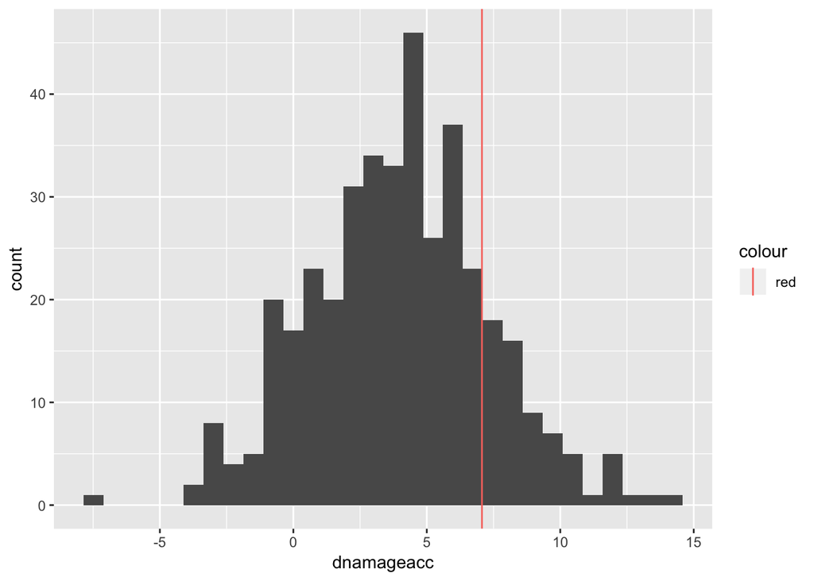

```r
her.dnam <- dan.new %>% filter(uncchdid == "21016") %>% pull(dnamageacc)


dan.new %>% select(uncchdid, numbpreg, dnamageacc) %>% ggplot2::ggplot(aes(x = dnamageacc)) +
    geom_histogram() + geom_vline(aes(xintercept = her.dnam, col = "red"))
```

What if I plot them all - where do they fall?

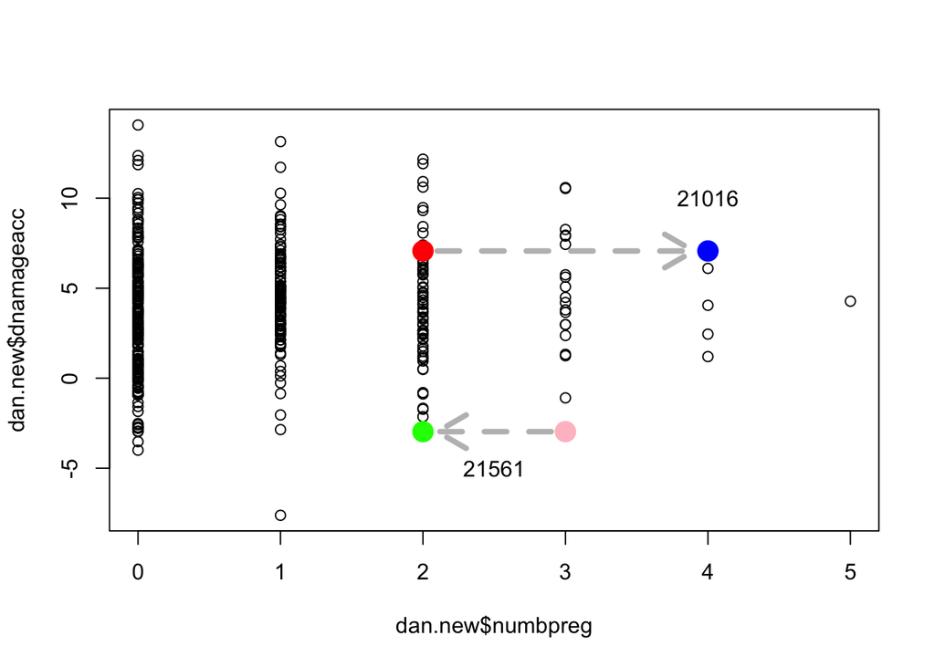

```r
plot(dan.new$dnamageacc ~ dan.new$numbpreg)
points(2, her.dnam, col = "red", pch = 19, cex = 2)  # Chris's 'Corrected' Value
points(4, her.dnam, col = "blue", pch = 19, cex = 2)  # 'True' Value - including miscarriages
arrows(x0 = 2.1, y0 = her.dnam, x1 = 3.9, y1 = her.dnam, col = "gray", lty = 2,
    lwd = 4)
text(x = 4, y = 10, "21016")

points(3, -2.96933, col = "pink", pch = 19, cex = 2)  # 'Corrected' Value)
points(2, -2.96933, col = "green", pch = 19, cex = 2)  # 'Corrected' Value)
arrows(x0 = 2.9, y0 = -2.96933, x1 = 2.1, y1 = -2.96933, col = "gray", lty = 2,
    lwd = 4)
text(x = 2.5, y = -5, "21561")
```

Wow - it strikes me that the original value is actually quite consistent with the CoR data.

I’m strongly inclined to keep these values. Matter of fact I should check all models with these in. I have a strong feeling that that last model will return to significance.

```r
# write_csv(repro_final.nsf_whole, here::here('Output/Data',
# 'repro_final_nsf_whole.csv'))
```